# Historical contingency in the evolution of antibiotic resistance after decades of relaxed selection

# Purpose

This R Markdown contains code used to analyze:

1. The intrinsic antibiotic resistance of the LTEE ancestor and derived generation 50,000 strains to determine whether resistance decays during evolution in the absence of drug exposure.
2. Each strain’s resistance evolvability in the presence of these drugs.
3. Intrinsic tetracycline resistance and subsequent evolvability of a time-series of clones isolated from the Ara+5 population across the first 10,000 generations.

It also generates all associated figures.

**NOTE: The .csv data files and this R Markdown need to be placed in the same directory first!**

## Prerequisites

Clear current environment

```r
rm(list = ls())
```

Load packages for use

```r
library(tidyverse) # Version 1.2.1
library(metap) # Version 1.1
library(DescTools) # Version 0.99.28
library(binom) # Version 1.1-1
library(cowplot) # Version 1.0.0
library(gridExtra) # Version 2.3
library(ggrepel) # Version 0.8.1
```

```r
anc.derived.strains <- c("Ancestor", "Ara\u20135", "Ara\u20136", "Ara+4", "Ara+5") # "\u2013" is unicode for "en dash"
derived.strains <- c("Ara\u20135", "Ara\u20136", "Ara+4", "Ara+5") # "\u2013" is unicode for "en dash"
ara5.strains <- c("0", "0.5A", "0.5B", "1A", "1B", "1.5B", "1.5A", "2A", "2B", "5A", "5B", "10A", "10B")
antibiotics <- c("amp", "cro", "cip", "tet")
genotypes <- c("parent", "daughter")
panel.titles <- c("Ampicillin", "Ceftriaxone", "Ciprofloxacin", "Tetracycline")
fluctuation.strains <- c("REL606", "REL1162A")
bounds <- c("lower", "upper")
```

# Data transformation and wrangling

Reads in *MICs of LTEE ancestral and derived strains* data showing the minimum inhibitory concentrations (MICs) of various antibiotics (ampicillin, ceftriaxone, ciprofloxacin, and tetracycline) on the LTEE ancestral and generation 50,000 derived clones (Ara-5, Ara-6, Ara+4, and Ara+5), and their evolved resistant mutants. The code then performs a binary logarithmic transformation of the MIC data to match the two-fold dilution scheme of the evolvability assays. Lastly, it performs data wrangling steps for downstream work.

```r
df <- read.csv("MICs of LTEE ancestral and derived strains.csv")

# Add row ID variable that will be used in data wrangling to determine each clone's resistance evolvability.
df$row.ID <- 1:nrow(df)

log2.df <- df %>%
  gather(genotype, MIC, amp.parent:tet.daughter)

# Binary logarithm transformation
log2.df$MIC <- log2(log2.df$MIC)

# Expand the genotype column into two separate columns containing information about the antibiotic and genotype for each clone.
ExpandData <- function(dat, antibiotics) {
  expand.dat <- dat %>%
    filter(grepl(antibiotics, genotype)) %>%
    add_column(antibiotic = antibiotics, .after = 1) %>%
    mutate(genotype = replace(genotype, genotype == paste(antibiotics, ".parent", sep = ""), "parent")) %>%
    mutate(genotype = replace(genotype, genotype == paste(antibiotics, ".daughter", sep = ""), "daughter"))
}

expanded.df <- map(antibiotics, function(x) {ExpandData(log2.df, x)}) %>%
  bind_rows()
```

Performs similar transformation on *MICs of strains from Ara+5 population* data.

```r
ara5.df <- read.csv("MICs of strains from Ara+5 population.csv")

ara5.df$row.ID <- 1:nrow(ara5.df)
log2.ara5.df <- ara5.df %>%
  gather(genotype, MIC, parent:daughter)

# Binary logarithm transformation
log2.ara5.df$MIC <- log2(log2.ara5.df$MIC)
```

Reads in *Mutant colony counts* data showing the number of tetracycline resistant clones derived from 84 independent populations each of the LTEE ancestor (REL606) and clone A isolated from the Ara+5 population after 2,000 generations (REL1162A). These data are used in the fluctuation analysis below.

```r
colony.counts.df <- read.csv("Mutant colony counts.csv")
```

Reads in *Cell counts* data showing the number of cell counts from 12 independent populations each of the LTEE ancestor (REL606) and clone A isolated from the Ara+5 population after 2,000 generations (REL1162A). These data are used in the fluctuation analysis below.

```r
cell.counts.df <- read.csv("Cell counts.csv")
```

# Data analysis

## Maintenance of intrinsic resistance during relaxed selection in the LTEE

We compare the MIC value of each derived clone (Ara-5, Ara-6, Ara+4, and Ara+5) with its corresponding paired ancestral value. We expected that the bacteria would evolve to be more susceptible to antibiotics given the absence of drug exposure during the LTEE. The derived clones should have lower MICs as a consequence. If this history of relaxed selection has no effect on susceptibility then a derived clone’s MIC could be lower, higher, or equal to its ancestral counterpart. On the one hand, numerical ties are conventionally excluded from these analyses, and the null hypothesis is that positive and negative differences are distributed by the binomial distribution where $p = 0.5$ (Dixon and Mood, 1946). On the other hand, Wittkowski (1989) argues that the omission of ties is inadvisable when they can be interpreted as non-zero differences that are too small to be observable, usually by rounding error. Moreover, Bian, McAleer, and Wong (2011) argue the omission of ties leads to loss of information and substantially reduced statistical power. They introduce the *trinomial test* that includes numerical ties effectively. We therefore use this statistical test here and elsewhere in our study.

If a derived clone has a lower MIC value than its paired ancestral value (expectation), then it is assigned a dummy value of 1. If not, it is assigned a value of 0 or -1 if it’s tied or higher, respectively. The trinomial test is performed for each strain and the resulting significance probabilities are then combined using Fisher’s method (Fisher, 1934) (Sokal and Rohlf, 1994).

```r
# Assigns "dummy" variables for each comparison
DummyVariables.RS <- function(dat) { # "RS" denotes "relaxed selection". A modified version of this function, to calculate evolvability *p*-values, is used below.
  ancestor.frame <- dat %>%
    filter(strain == "Ancestor", genotype == "parent")

  derived.frame <- dat %>%
    filter(strain %in% derived.strains, genotype == "parent")

  compare.values <- c()

  for(i in 1:nrow(derived.frame)) {
    derived.row <- derived.frame[i,]
    pairedID <- derived.row$paired.ID
    ab <- derived.row$antibiotic
    ancestor.row <- filter(ancestor.frame, paired.ID == pairedID, antibiotic == ab)
    compare.values <- c(compare.values, ifelse(derived.row$MIC < ancestor.row$MIC, 1,
                                               ifelse(derived.row$MIC == ancestor.row$MIC, 0, -1)))
  }

  remove.cols.frame <- derived.frame %>%
    select(-(paired.ID:MIC))

  remove.cols.frame$dummy <- compare.values

  return(remove.cols.frame)
}

dummy.rs.df <- DummyVariables.RS(expanded.df)

# Computes the *p*-value for each strain using the trinomial test
TrinomialTest <- function(dat) {

  n.pos <- dat %>%
    filter(dummy == 1) %>%
    nrow()

  n.ties <- dat %>%
    filter(dummy == 0) %>%
    nrow()

  n.neg <- dat %>%
    filter(dummy == -1) %>%
    nrow()

  n <- n.pos + n.ties + n.neg
  nd <- abs(n.pos - n.neg)
  p.ties <- n.ties / (n.pos + n.ties + n.neg) # Unbiased estimate of the probability of numerical ties (Bian, McAleer, and Wong 2011)
  x <- (n - nd) / 2

  prob <- c()

  for(k in 0:x) {
    test <- (factorial(n)) / (factorial(nd + k) * factorial(k) * factorial(n - nd - 2*k)) *
      (((1 - p.ties) / 2) ^ (nd + (2*k))) *
      ((p.ties) ^ (n - nd - 2*k))

    prob <- c(prob, test)
  }

# If the differences are in the direction of expectation given the alternative, then determine P(Nd) as described in Bian, McAleer, and Wong (2011). If the differences are in the direction *opposite* expectation, then 1 - P(Nd).
  sum.prob <- sum(prob)
  corrected.sum.prob <- ifelse(n.pos >= n.neg, sum.prob, (1 - sum.prob))

  return(corrected.sum.prob)
}

pvalues.rs <- c()

for (i in unique(antibiotics)) {
  ab.subset <- dummy.rs.df %>%
    filter(antibiotic == i)

  for(j in unique(derived.strains)) {
    strain.subset <- ab.subset %>%
      filter(strain == j)

    pvalues.rs <- c(pvalues.rs, TrinomialTest(strain.subset))
  }
}

# This data frame corresponds to S1 Table
pval.rs.df <- data.frame(
  strain = rep(derived.strains, 4),
  antibiotic = rep(antibiotics, each = 4),
  p = pvalues.rs
  )

# Combines *p*-values by the sum of logs (Fisher's) method
CalculateCombinedPValues <- function(dat, ab) {
  ab.filter <- dat %>%
    filter(antibiotic == ab)

  sum.log.method <- sumlog(ab.filter$p)

  return(sum.log.method)
}

combined.pval.rs.df <- map(antibiotics, function(x) {CalculateCombinedPValues(pval.rs.df, x)})
names(combined.pval.rs.df) <- antibiotics

print(combined.pval.rs.df)
```

```
$`amp`
chisq =  40.06389  with df =  8  p =  3.117107e-06

$cro
chisq =  45.32771  with df =  8  p =  3.189362e-07

$cip
chisq =  27.14749  with df =  8  p =  0.000666695

$tet
chisq =  41.40488  with df =  8  p =  1.750897e-06
```

## Evolvability of antibiotic resistance in the LTEE

We show with trinomial tests, and subsequent meta-analyses, that the derived clones have become more susceptible during evolution in the absence of antibiotic exposure in the LTEE. Under a *diminishing-returns* model, backgrounds with lower initial resistance are more evolvable than backgrounds that are initially more resistant. On balance, evolved clones would therefore evolve more resistance relative to their paired ancestors. Conversely, if evolvability is not correlated with the initial level of resistance, and hence *idiosyncratic*, then a derived clone’s MIC could be lower, higher, or equal to its ancestral counterpart. We use the trinomial test to examine the former trend, and Kruskal-Wallis one-way ANOVA for the latter.

If a derived clone is more evolvable than its paired ancestor, then it is assigned a dummy value of 1. If not, it is assigned a value of 0 or -1 if it’s tied or lower, respectively. The trinomial test is performed for each strain and the resulting significance probabilities are then combined using Fisher’s method.

```r
# Calculates evolvability of each strain
CalculateEvolvability <- function(dat) {
  parental.frame <- dat %>%
    filter(genotype == "parent")

  daughter.frame <- dat %>%
    filter(genotype == "daughter")

  evolvability.values <- c()

  for(i in 1:nrow(daughter.frame)) {
    daughter.row <- daughter.frame[i,]
    rowID <- daughter.row$row.ID
    ab <- daughter.row$antibiotic
    parent.row <- filter(parental.frame, row.ID == rowID, antibiotic == ab)
    evolvability.values <- c(evolvability.values, round(daughter.row$MIC - parent.row$MIC))
  }

  remove.cols.frame <- daughter.frame %>%
    select(-genotype, -MIC)

  remove.cols.frame$evolvability <- evolvability.values

  return(remove.cols.frame)
}

evolvability.df <- CalculateEvolvability(expanded.df)

# Assigns "dummy" variables for each comparison
DummyVariables.Evo <- function(dat) { # "Evo" denotes "evolvability".
  ancestor.frame <- dat %>%
    filter(strain == "Ancestor")

  derived.frame <- dat %>%
    filter(strain %in% derived.strains)

  compare.values <- c()

  for(i in 1:nrow(derived.frame)) {
    derived.row <- derived.frame[i,]
    pairedID <- derived.row$paired.ID
    ab <- derived.row$antibiotic
    ancestor.row <- filter(ancestor.frame, paired.ID == pairedID, antibiotic == ab)
    compare.values <- c(compare.values, ifelse(derived.row$evolvability > ancestor.row$evolvability, 1,
                                               ifelse(derived.row$evolvability == ancestor.row$evolvability, 0, -1)))
  }

  remove.cols.frame <- derived.frame %>%
    select(-(paired.ID:evolvability))

  remove.cols.frame$dummy <- compare.values

  return(remove.cols.frame)
}

dummy.evo.df <- DummyVariables.Evo(evolvability.df)

# Computes the *p*-value for each strain using the trinomial test
pvalues.evo <- c()

for (i in unique(antibiotics)) {
  ab.subset <- dummy.evo.df %>%
   filter(antibiotic == i)

  for(j in unique(derived.strains)) {
    strain.subset <- ab.subset %>%
      filter(strain == j)

    pvalues.evo <- c(pvalues.evo, TrinomialTest(strain.subset))
  }
}

# This data frame corresponds to S2 Table
pval.evo.df <- data.frame(
  strain = rep(derived.strains, 4),
  antibiotic = rep(antibiotics, each = 4),
  p = pvalues.evo
  )

# Combines *p*-values by the sum of logs (Fisher's) method
combined.pval.evo.df <- map(antibiotics, function(x) {CalculateCombinedPValues(pval.evo.df, x)})
names(combined.pval.evo.df) <- antibiotics

print(combined.pval.evo.df)
```

```
$`amp`
chisq =  14.62556  with df =  8  p =  0.06684829

$cro
chisq =  0.1752116  with df =  8  p =  0.9999977

$cip
chisq =  7.876327  with df =  8  p =  0.4456433

$tet
chisq =  5.965134  with df =  8  p =  0.6511376
```

Under the *idiosyncratic* increases model, resistance gains are not correlated with the initial level of resistance. We therefore perform a non-parametric ANOVA (Kruskal-Wallis test).

```r
PerformKWTest <- function(dat, ab) {
  ab.filter <- dat %>%
    filter(antibiotic == ab)

  kruskal.wallis.test <- kruskal.test(x = ab.filter$evolvability, g = ab.filter$strain)

  return(kruskal.wallis.test)
}

kw.results <- map(antibiotics, function(x) {PerformKWTest(evolvability.df, x)})
names(kw.results) <- antibiotics
print(kw.results)
```

```
$`amp`

    Kruskal-Wallis rank sum test

data:  ab.filter$evolvability and ab.filter$strain
Kruskal-Wallis chi-squared = 9.1882, df = 4, p-value = 0.05656


$cro

    Kruskal-Wallis rank sum test

data:  ab.filter$evolvability and ab.filter$strain
Kruskal-Wallis chi-squared = 23.447, df = 4, p-value = 0.0001031


$cip

    Kruskal-Wallis rank sum test

data:  ab.filter$evolvability and ab.filter$strain
Kruskal-Wallis chi-squared = 7.593, df = 4, p-value = 0.1077


$tet

    Kruskal-Wallis rank sum test

data:  ab.filter$evolvability and ab.filter$strain
Kruskal-Wallis chi-squared = 10.175, df = 4, p-value = 0.03759
```

## Maintenance of intrinsic tetracycline resistance and evolvability of strains isolated from the Ara+5 population

We examined when the Ara+5 population lost the capacity to evolve tetracycline resistance by testing two strains (denoted “A” and “B”) isolated from this population at generations 500, 1,000, 1,500, 2,000, 5,000, and 10,000. We first examine whether both i.) intrinsic and ii.) evolved tetracycline resistance levels differ between these backgrounds using Kruskal-Wallis tests. We then compare each derived strain to the ancestor using Dunnett’s test.

```r
PerformKWTest.Ara5 <- function(dat, gen) {
  genotype.filter <- dat %>%
    filter(genotype == gen)

  kruskal.wallis.test <- kruskal.test(x = genotype.filter$MIC, g = genotype.filter$strain)

  return(kruskal.wallis.test)
}

PerformDunnettTest <- function(dat, gen) {
  genotype.filter <- dat %>%
    filter(genotype == gen)

  dunnett.test <- DunnettTest(x = genotype.filter$MIC, g = genotype.filter$strain, control = "0")
}

kw.results.ara5 <- map(genotypes, function(x) {PerformKWTest.Ara5(log2.ara5.df, x)})
names(kw.results.ara5) <- paste("Ara+5", genotypes, sep = " ")
print(kw.results.ara5)
```

```
$`Ara+5 parent`

    Kruskal-Wallis rank sum test

data:  genotype.filter$MIC and genotype.filter$strain
Kruskal-Wallis chi-squared = 64.641, df = 12, p-value = 3.176e-09


$`Ara+5 daughter`

    Kruskal-Wallis rank sum test

data:  genotype.filter$MIC and genotype.filter$strain
Kruskal-Wallis chi-squared = 86.399, df = 12, p-value = 2.449e-13
```

```r
dunnett.results.ara5 <- map(genotypes, function(x) {PerformDunnettTest(log2.ara5.df, x)})
names(dunnett.results.ara5) <- paste("Ara+5", genotypes, sep = " ")
print(dunnett.results.ara5)
```

```
$`Ara+5 parent`

  Dunnett's test for comparing several treatments with a control :
    95% family-wise confidence level

$`0`
       diff     lwr.ci      upr.ci    pval
0.5A-0  0.0 -0.3077088  0.30770881  1.0000
0.5B-0  0.0 -0.3077088  0.30770881  1.0000
1.5A-0  0.0 -0.3077088  0.30770881  1.0000
1.5B-0 -0.8 -1.1077088 -0.49229119 1.7e-10 ***
10A-0  -0.4 -0.7077088 -0.09229119  0.0041 **
10B-0  -0.3 -0.6077088  0.00770881  0.0599 .
1A-0    0.0 -0.3077088  0.30770881  1.0000
1B-0    0.0 -0.3077088  0.30770881  1.0000
2A-0    0.0 -0.3077088  0.30770881  1.0000
2B-0    0.0 -0.3077088  0.30770881  1.0000
5A-0   -0.1 -0.4077088  0.20770881  0.9722
5B-0    0.0 -0.3077088  0.30770881  1.0000

---
Signif. codes:  0 '***' 0.001 '**' 0.01 '*' 0.05 '.' 0.1 ' ' 1


$`Ara+5 daughter`

  Dunnett's test for comparing several treatments with a control :
    95% family-wise confidence level

$`0`
       diff     lwr.ci      upr.ci    pval
0.5A-0 -0.3 -0.8029348  0.20293483 0.51397
0.5B-0 -0.3 -0.8029348  0.20293483 0.51372
1.5A-0 -0.6 -1.1029348 -0.09706517 0.01047 *
1.5B-0 -1.1 -1.6029348 -0.59706517 5.6e-08 ***
10A-0  -1.6 -2.1029348 -1.09706517 1.9e-14 ***
10B-0  -1.6 -2.1029348 -1.09706517 2.5e-14 ***
1A-0    0.0 -0.5029348  0.50293483 1.00000
1B-0   -0.2 -0.7029348  0.30293483 0.90175
2A-0   -1.0 -1.5029348 -0.49706517 1.3e-06 ***
2B-0   -0.8 -1.3029348 -0.29706517 0.00019 ***
5A-0   -0.8 -1.3029348 -0.29706517 0.00019 ***
5B-0   -1.2 -1.7029348 -0.69706517 4.9e-09 ***

---
Signif. codes:  0 '***' 0.001 '**' 0.01 '*' 0.05 '.' 0.1 ' ' 1
```

Lastly, we examine whether the tetracycline resistance evolvability significantly differs between Ara+5 strains, and then compare each derived strain to the ancestor using Dunnett’s test.

```r
# Calculates evolvability values for each Ara+5 strain
CalculateEvolvability.Ara5 <- function(dat) {
  parental.frame <- dat %>%
    filter(genotype == "parent")

  daughter.frame <- dat %>%
    filter(genotype == "daughter")

  evolvability.values <- c()

  for(i in 1:nrow(daughter.frame)) {
    row <- daughter.frame[i,]
    rowID <- row$row.ID
    parent <- filter(parental.frame, row.ID == rowID)
    evolvability.values <- c(evolvability.values, round(row$MIC - parent$MIC))
  }

  remove.cols.frame <- daughter.frame %>%
    select(-(row.ID:MIC))

  remove.cols.frame$evolvability <- evolvability.values

  return(remove.cols.frame)
}

evolvability.ara5.df <- CalculateEvolvability.Ara5(log2.ara5.df)

kw.results.evo.ara5 <- kruskal.test(x = evolvability.ara5.df$evolvability, g = evolvability.ara5.df$strain)
print(kw.results.evo.ara5)
```

```
    Kruskal-Wallis rank sum test

data:  evolvability.ara5.df$evolvability and evolvability.ara5.df$strain
Kruskal-Wallis chi-squared = 67.891, df = 12, p-value = 7.929e-10
```

```r
dunnett.results.evo.ara5 <- DunnettTest(x = evolvability.ara5.df$evolvability, g = evolvability.ara5.df$strain, control = "0")
print(dunnett.results.evo.ara5)
```

```
  Dunnett's test for comparing several treatments with a control :
    95% family-wise confidence level

$`0`
       diff     lwr.ci      upr.ci    pval
0.5A-0 -0.3 -0.8849937  0.28499368  0.6921
0.5B-0 -0.3 -0.8849937  0.28499368  0.6920
1.5A-0 -0.6 -1.1849937 -0.01500632  0.0412 *
1.5B-0 -0.3 -0.8849937  0.28499368  0.6920
10A-0  -1.2 -1.7849937 -0.61500632 9.1e-07 ***
10B-0  -1.3 -1.8849937 -0.71500632 7.8e-08 ***
1A-0    0.0 -0.5849937  0.58499368  1.0000
1B-0   -0.2 -0.7849937  0.38499368  0.9607
2A-0   -1.0 -1.5849937 -0.41500632 4.8e-05 ***
2B-0   -0.8 -1.3849937 -0.21500632  0.0021 **
5A-0   -0.7 -1.2849937 -0.11500632  0.0101 *
5B-0   -1.2 -1.7849937 -0.61500632 6.8e-07 ***

---
Signif. codes:  0 '***' 0.001 '**' 0.01 '*' 0.05 '.' 0.1 ' ' 1
```

## Fluctuation analyses

We performed fluctuation analyses to compare the effective mutation rates to tetracycline resistance for the LTEE ancestor and clone A isolated from the Ara+5 population after 2,000 generations.

```r
# Test for normality and equal variance assumptions of the cell count data
TestAssumptions <- function(dat){
  anc.frame <- dat %>%
    filter(strain == "REL606")

  evo.frame <- dat %>%
    filter(strain == "REL1162A")

  normality <- c()
  for(i in unique(dat$strain)){
    strain.frame <- dat %>%
      filter(strain == i)

    normality <- c(normality, (shapiro.test(strain.frame$cell.count)))
  }

  variance <- var.test(anc.frame$cell.count, evo.frame$cell.count, alternative = "two.sided")

  t.assumptions <- list(normality, variance)

  return(t.assumptions)
}

test.assumptions <- TestAssumptions(cell.counts.df)
names(test.assumptions) <- c("Shapiro-Wilk test", "F-test")
print(test.assumptions)
```

```
$`Shapiro-Wilk test`
$`Shapiro-Wilk test`$`statistic`
        W
0.9423613

$`Shapiro-Wilk test`$p.value
[1] 0.529255

$`Shapiro-Wilk test`$method
[1] "Shapiro-Wilk normality test"

$`Shapiro-Wilk test`$data.name
[1] "strain.frame$cell.count"

$`Shapiro-Wilk test`$statistic
        W
0.9791516

$`Shapiro-Wilk test`$p.value
[1] 0.9800513

$`Shapiro-Wilk test`$method
[1] "Shapiro-Wilk normality test"

$`Shapiro-Wilk test`$data.name
[1] "strain.frame$cell.count"


$`F-test`

    F test to compare two variances

data:  anc.frame$cell.count and evo.frame$cell.count
F = 8.708, num df = 11, denom df = 11, p-value = 0.001191
alternative hypothesis: true ratio of variances is not equal to 1
95 percent confidence interval:
  2.506834 30.248926
sample estimates:
ratio of variances
          8.707987
```

```r
# Both strains have normally distributed cell counts with unequal variances. We therefore perform a Welch's t-test
TTest <- function(dat){
  anc.frame <- dat %>%
    filter(strain == "REL606")

  evo.frame <- dat %>%
    filter(strain == "REL1162A")

  ttest <- t.test(anc.frame$cell.count, evo.frame$cell.count, alternative = "two.sided", var.equal = FALSE)

  return(ttest)
}

t.test.cell.yield <- TTest(cell.counts.df)
print(t.test.cell.yield)
```

```
    Welch Two Sample t-test

data:  anc.frame$cell.count and evo.frame$cell.count
t = 6.4063, df = 13.494, p-value = 1.948e-05
alternative hypothesis: true difference in means is not equal to 0
95 percent confidence interval:
  6472.999 13023.335
sample estimates:
mean of x mean of y
18159.583  8411.417
```

```r
# Calculates the mean final number of cells in diluted samples
CalculateMeanYields <- function(dat, strains) {
  strain.frame <- dat %>%
    filter(strain == strains)

  mean.cell.yield <- mean(strain.frame$cell.count)

  return(mean.cell.yield)
}

cell.yields <- map(fluctuation.strains, function(x){CalculateMeanYields(cell.counts.df, x)})
names(cell.yields) <- fluctuation.strains
print(cell.yields)
```

```
$`REL606`
[1] 18159.58

$REL1162A
[1] 8411.417
```

```r
# Each replicate population was diluted 10,000-fold for quantification of cell yields
dilution.factor <- 10000

# True mean cell counts taking the dilution factor into consideration
cell.yields <- Map("*", cell.yields, dilution.factor)

# Estimates the expected number of mutational events per culture for both strains
EstimateME <- function(dat, strains) {
  strain.frame <- dat %>%
    filter(strain == strains)

  zero.count <- strain.frame %>%
    filter(n.colonies == 0) %>%
    nrow()

  n.replicates <- strain.frame %>%
    nrow()

  zeros <- zero.count
  p0 <- zero.count / n.replicates # Proportion of replicate cultures without mutants
  m <- -log(p0) # Expected number of mutational events

  fluc.test.parameters <- data.frame(zeros, n.replicates, p0, m)

  return(fluc.test.parameters)
}

ft.parameters <- map(fluctuation.strains, function(x){EstimateME(colony.counts.df, x)})
names(ft.parameters) <- fluctuation.strains
print(ft.parameters)
```

```
$`REL606`
  zeros n.replicates        p0         m
1    73           84 0.8690476 0.1403574

$REL1162A
  zeros n.replicates        p0         m
1    58           84 0.6904762 0.3703738
```

```r
# Estimates the mutation rate to tetracycline resistance for both strains and the 95% CIs of these point estimates
EstimateMR <- function(fluc.param, c.yields, strains){
  # Subsets the ft.parameters list by strain
  strain.df <- fluc.param[[strains]]

  n.zeros <- strain.df$zeros
  n.replicates <- strain.df$n.replicates
  m.events <- strain.df$m

  # Subsets the cell yield data for the given strain
  yield <- c.yields[[strains]]

  mutation.rate <- m.events / yield

  # Estimation of 95% confidence intervals for the binomial proportion of zero mutant counts (p0)
  p0.CIs <- binom.confint(x = strain.df$zeros,
                       n = strain.df$n.replicates,
                       conf.level = 0.95,
                       methods = "ac")

  # Estimates the lower and upper bound 95% CIs of strain mutation rate to tetracycline resistance
  mutation.rate.CI <- c()

  for(bound in bounds){
    m.CI <- -log(p0.CIs[bound])
    mutation.rate.CI <- c(mutation.rate.CI, (m.CI / yield))
  }

  output <- data.frame(mutation.rate, mutation.rate.CI)

  return(output)
}

mutation.rates <- map(fluctuation.strains, function(x){EstimateMR(ft.parameters, cell.yields, x)})
names(mutation.rates) <- fluctuation.strains

print(mutation.rates)
```

```
$`REL606`
  mutation.rate        lower        upper
1  7.729107e-10 1.376418e-09 4.175465e-10

$REL1162A
  mutation.rate        lower        upper
1  4.403227e-09 6.378659e-09 2.961146e-09
```

# Figures

Figs 1 and S1 were made using Inkscape 0.92. All figures from the main text and Supplementary Information have been deposited on the open-access repository Figshare, and are thus freely available to use, modify, and share.

Fig 2 - Intrinsic resistance usually declined over time in the absence of drug exposure.

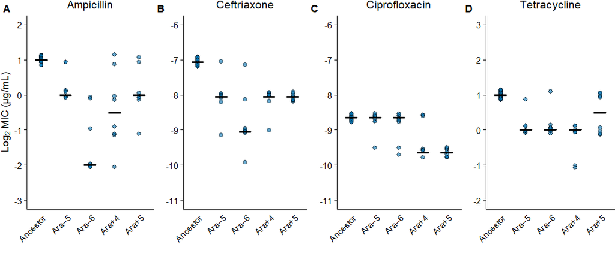

```r
# Function to generate each figure panel
GenerateFig2 <- function(dat, ab, panel.title, y.label, y.limit, y.breaks) {
  filtered.frame <- dat %>%
    filter(antibiotic == ab, genotype == "parent")


  panel.plot <- ggplot(filtered.frame, aes(x = strain, y = MIC)) +
    geom_jitter(height = 0.15, width = 0, alpha = 0.6, size = 2.5, pch = 21, fill = "#0072B2", color = "#000000") +
    stat_summary(fun.y = median, fun.ymin = median, fun.ymax = median,
               geom = "crossbar", width = 0.5, color = "#000000") +
    ggtitle(panel.title) +
    labs(y = y.label, x = "") +
    scale_y_continuous(limit = y.limit, breaks = y.breaks) +
    theme_set(theme_cowplot()) +
    theme(axis.ticks.x = element_blank(),
          axis.text.x = element_text(angle = 45, hjust = 1),
          plot.title = element_text(face = "plain", hjust = 0.5),
          plot.margin = unit(c(0, 0, 0, 0), "cm"))

  return(panel.plot)
}

# Panels
fig.2a <- GenerateFig2(expanded.df, "amp", "Ampicillin", expression("Log"[2]~"MIC (\u03BCg/mL)"), c(-3, 2), c(-3, -2, -1, 0, 1, 2))
fig.2b <- GenerateFig2(expanded.df, "cro", "Ceftriaxone", "", c(-11, -6), c(-11, -10, -9, -8, -7, -6))
fig.2c <- GenerateFig2(expanded.df, "cip", "Ciprofloxacin", "", c(-11, -6), c(-11, -10, -9, -8, -7, -6))
fig.2d <- GenerateFig2(expanded.df, "tet", "Tetracycline", "", c(-2, 3), c(-2, -1, 0, 1, 2, 3))

fig.2 <- plot_grid(fig.2a, fig.2b, fig.2c, fig.2d, labels = c("A", "B", "C", "D"), label_fontface = "bold", nrow = 1)
print(fig.2)
```

```r
# ggsave("fig2.png", fig.2, path = "Figures", device = "png", width = 12, height = 5)
```

Fig. 3 - Genetic background affects the evolvability of LTEE lines exposed to antibiotics.

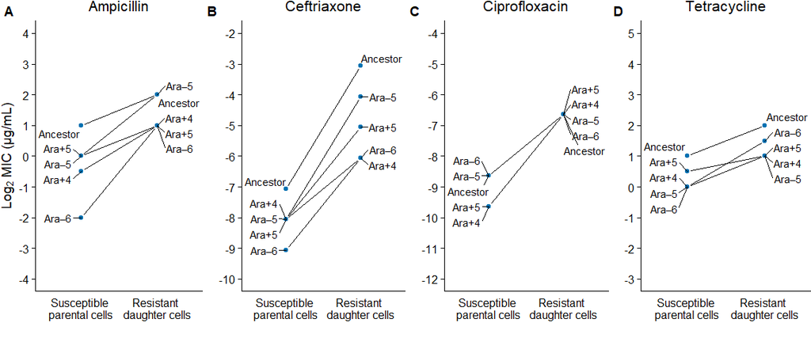

```r
# Computes the median MIC for each strain and antibiotic combination
med.MIC <- c()

for (i in unique(antibiotics)) {
  ab.filter <- expanded.df %>%
    filter(antibiotic == i)

  for(j in unique(anc.derived.strains)) {
    strain.filter <- ab.filter %>%
      filter(strain == j)

    for(k in unique(genotypes)) {
      genotype.filter <- strain.filter %>%
        filter(genotype == k)

      med.MIC <- c(med.MIC, median(genotype.filter$MIC))
    }
  }
}

med.MIC.df <- data.frame(
  strain = rep(anc.derived.strains, each = 2) %>% rep(4),
  antibiotic = rep(antibiotics, each = 10),
  genotype = rep(genotypes, 20),
  median = med.MIC
)

GenerateFig3 <- function(dat, ab, panel.title, y.label, y.limit, y.breaks) {
  # Prep data
  ab.frame <- dat %>%
    filter(antibiotic == ab)

  parental.frame <- ab.frame %>%
    filter(genotype == "parent") %>%
    spread(genotype, median) %>%
    rename("parent.med" = "parent")

  daughter.frame <- ab.frame %>%
    filter(genotype == "daughter") %>%
    spread(genotype, median) %>%
    rename("daughter.med" = "daughter")

  master.frame <- left_join(parental.frame, daughter.frame, by = c("strain", "antibiotic"))

  left.label <- master.frame$strain
  right.label <- master.frame$strain

  # Plot
  panel.plot <- ggplot(master.frame) +
    geom_segment(aes(x = 1, xend = 2, y = parent.med, yend = daughter.med, col = class),
                 color = "black", show.legend = F) +
    geom_point(aes(x = 1, y = parent.med), size = 2.5, pch = 21, fill = "#0072B2", color = "#ffffff", stroke = 1.5) +
    geom_point(aes(x = 2, y = daughter.med), size = 2.5, pch = 21, fill = "#0072B2", color = "#ffffff", stroke = 1.5) +
    geom_text_repel(label = left.label, x = rep(1, nrow(master.frame)), y = master.frame$parent.med, direction = "y", nudge_x = -0.3, segment.size = 0.2) +
    geom_text_repel(label = right.label, x = rep(2, nrow(master.frame)), y = master.frame$daughter.med, direction = "y", nudge_x = 0.3, segment.size = 0.2) +
    ggtitle(panel.title) +
    labs(y = y.label, x = "") +
    scale_x_discrete(limits = c("Susceptible \nparental cells", "Resistant \ndaughter cells")) +
    scale_y_continuous(limit = y.limit, breaks = y.breaks) +
    theme_set(theme_cowplot()) +
    theme(axis.ticks.x = element_blank(),
          plot.title = element_text(face = "plain", hjust = 0.5),
          plot.margin = unit(c(0, 0, 0, 0), "cm"))

  return(panel.plot)
}

# Panels
fig.3a <- GenerateFig3(med.MIC.df, "amp", "Ampicillin", expression("Log"[2]~"MIC (\u03BCg/mL)"), c(-4, 4), c(-4, -3, -2, -1, 0, 1, 2, 3, 4))
fig.3b <- GenerateFig3(med.MIC.df, "cro", "Ceftriaxone", "", c(-10, -2), c(-10, -9, -8, -7, -6, -5, -4, -3, -2))
fig.3c <- GenerateFig3(med.MIC.df, "cip", "Ciprofloxacin", "", c(-12, -4), c(-12, -11, -10, -9, -8, -7, -6, -5, -4))
fig.3d <- GenerateFig3(med.MIC.df, "tet", "Tetracycline", "", c(-3, 5), c(-3, -2, -1, 0, 1, 2, 3, 4, 5))

fig.3 <- plot_grid(fig.3a, fig.3b, fig.3c, fig.3d, labels = c("A", "B", "C", "D"), label_fontface = "bold", nrow = 1)
print(fig.3)
```

```r
# ggsave("fig3.png", fig.3, path = "Figures", device = "png", width = 15, height = 5)
```

Fig. 4 - Capacity to evolve resistance to tetracycline in a single step was diminished early in one LTEE lineage.

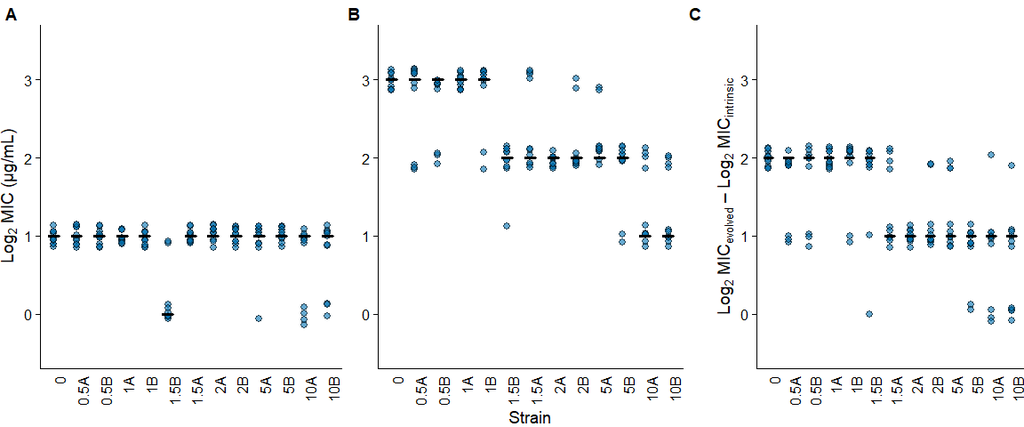

```r
# Function to generate figure 4, panels "A" and "B"
GenerateFig4.ab <- function(dat, gen, y.label, x.label) {
  genotype.frame <- dat %>%
    filter(genotype == gen)

  panel.ab.plot <- ggplot(genotype.frame, aes(x = strain, y = MIC)) +
    geom_jitter(height = 0.15, width = 0, alpha = 0.6, size = 2.5, pch = 21, fill = "#0072B2", color = "#000000") +
    stat_summary(fun.y = median, fun.ymin = median, fun.ymax = median,
                 geom = "crossbar", width = 0.5, color = "#000000") +
    labs(y = y.label, x = x.label) +
    scale_x_discrete(limits = ara5.strains) +
    scale_y_continuous(limit = c(-0.5, 3.5), breaks = c(0, 1, 2, 3)) +
    theme(axis.ticks.x = element_blank(),
          axis.text.x = element_text(angle = 90, hjust = 1),
          plot.margin = unit(c(0.75, 0, 0, 0), "cm"))

  return(panel.ab.plot)
}

# Panels
fig.4a <- GenerateFig4.ab(log2.ara5.df, "parent", expression("Log"[2]~"MIC (\u03BCg/mL)"), "")
fig.4b <- GenerateFig4.ab(log2.ara5.df, "daughter", "", "Strain")

# Code to generate figure 4, panel "C"
fig.4c <- ggplot(evolvability.ara5.df, aes(x = strain, y = evolvability)) +
  geom_jitter(height = 0.15, width = 0, alpha = 0.6, size = 2.5, pch = 21, fill = "#0072B2", color = "#000000") +
  stat_summary(fun.y = median, fun.ymin = median, fun.ymax = median,
               geom = "crossbar", width = 0.5, color = "#000000") +
  labs(y = expression("Log"[2]*" MIC"[evolved]*" \u2013 Log"[2]*" MIC"[intrinsic]), x = "") +
  scale_x_discrete(limits = ara5.strains) +
  scale_y_continuous(limit = c(-0.5, 3.5), breaks = c(0, 1, 2, 3)) +
  theme_set(theme_cowplot()) +
  theme(axis.ticks.x = element_blank(),
        axis.text.x = element_text(angle = 90, hjust = 1),
        plot.margin = unit(c(0.75, 0, 0, 1), "cm"))


fig.4 <- plot_grid(fig.4a, fig.4b, fig.4c, labels = c("A", "B", "C"), label_fontface = "bold", nrow = 1)
print(fig.4)
```

```r
# ggsave("fig4.png", fig.4, path = "Figures", device = "png", width = 12, height = 5)
```